# RNA-composition and DE

## Plotting distributions

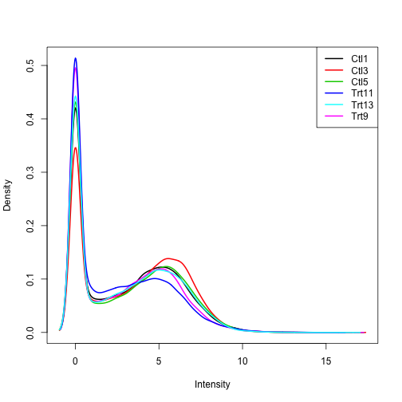

```r
# Pseoducount and log
plotDensities(log(zebrafish$Expression+1), legend="topright")
```

## Plotting distributions

Notice how the lower quartile is zero - this means that we have a large number of genes with very low counts.

Counts with 1-3 counts are not very interesting, since they are likely to be either noise or expressed at biologically irrelevant levels. It's customary to perform som ad-hoc trimming or filtering to remove these prior to analysis.

Here we only keep genes with at least 2 counts in at least 4 samples:

```r
# Trim
above_one <- rowSums(zebrafish$Expression > 1)

trimmed_em <- subset(zebrafish$Expression, above_one > 3)

# Pseoducount and log
log_trimmed_em <-  log(trimmed_em + 1)
```

## Plotting distributions

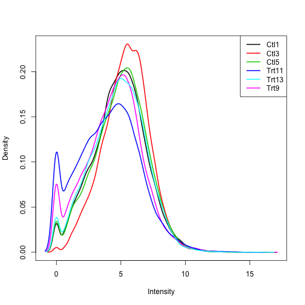

```r
plotDensities(log_trimmed_em, legend="topright")
```

## Plotting distributions

Now we have a clearer picture of the distribution of counts within each sample. The large difference in distributions shows the need for normalization, before the samples can be compared.

As with everything in R, we do not have to recode everything from scratch. The edgeR package has a function `cpm` which has implented a large number of normalization methods and log-transformation.

edgeR does this by implementing the use of normalization factors, which is use to rescale the actual library sizes to take into account differences in RNA-composition.

## Using edgeR to normalize

Using edgeR is simple, but first we must save the EM as a `DGEList`:

```r
# Create DGEList-object from the trimmed em
dge <- DGEList(trimmed_em)

# Use edgeR to calculate normalization factors
dge <- calcNormFactors(object=dge, method="TMM")

# calculate log cpm values
TMM_em <- cpm(x=dge, log=TRUE, prior.count=1.0)

head(TMM_em)
```

```
##                        Ctl1     Ctl3       Ctl5     Trt9      Trt11
## ENSDARG00000000001 2.863841 1.070888  2.9026167 1.876326 -0.4314598
## ENSDARG00000000002 3.854225 3.360984  3.1620111 1.563859  3.3678160
## ENSDARG00000000018 3.225830 1.928374  2.2617491 4.309565  4.3375880
## ENSDARG00000000019 6.152048 6.250098  7.2664067 8.029591  8.7165741
## ENSDARG00000000068 1.103626 2.524350 -0.1101648 2.419952  1.0285423
## ENSDARG00000000069 2.901188 1.578056  4.2156712 3.269221  4.5232027
##                       Trt13
## ENSDARG00000000001 3.987476
## ENSDARG00000000002 4.999126
## ENSDARG00000000018 3.860666
## ENSDARG00000000019 6.425998
## ENSDARG00000000068 0.207237
## ENSDARG00000000069 2.646674
```

## Using edgeR to normalize

The resulting plot shows a nicer alignment of the main peak:

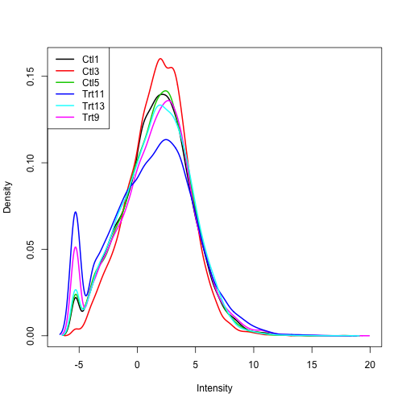

```r
plotDensities(TMM_em)
```

## log-log plots

Another way of visualizing normalization is via a log-log plot. This is simply a scatterplot with paired expression values for two samples.

Although it only allows for pairwise comparison, it is a nice way to see the effect of normalization and the variance of expression at different levels.

## log-log plots

First we consider the (trimmed) log(counts+1)

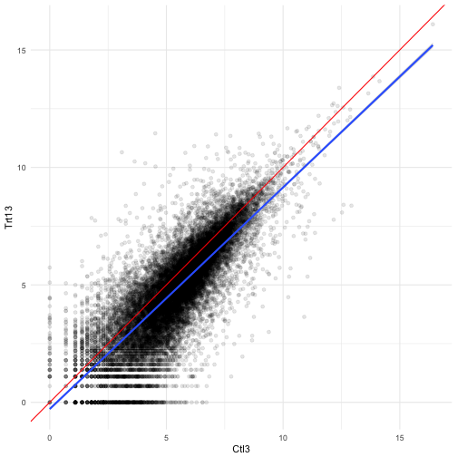

```r
qplot(data=log_trimmed_em, x=Ctl3, y=Trt13, alpha=I(0.1)) + geom_smooth(method="gam") + geom_abline(color="red")
```

## log-log plots

Compare this with edgeR's TMM normalization:

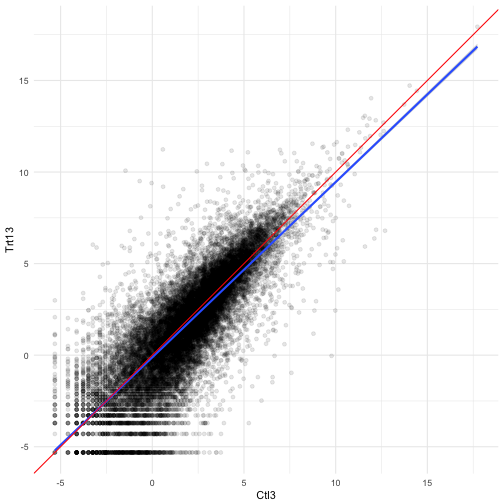

```r
qplot(data=as.data.frame(TMM_em), x=Ctl3, y=Trt13, alpha=I(0.1)) + geom_smooth(method="gam") + geom_abline(color="red")
```

## Exercises

Team up and do the following exercises:

1. Make a plot of density curves showing the effect of all the different normalization methods implemented by `edgeR`
2. Make a plot that compares the estimated normalization factors for the `TMM` and `RLE` normalization methods.
3. Investigate the effect of different pseudocount values using log-log plots.

*HINT for 1:* Use `apply`-family and facets to compare multiple datasets. Remember to include `method="none"`.

*HINT for 2:* Read the `calcNormFactors` help file to see where the normalization factors are stored

## Question 1 code

```r
# Convert to a DGElist
dge <- DGEList(trimmed_em)

# Normalize using each of four methods
edgeR_methods <- c("none", "TMM", "RLE", "upperquartile")
dges <- lapply(edgeR_methods, calcNormFactors, object=dge)

# Calculate CPMs
norms <- lapply(dges, cpm, log=TRUE)
```

## Question 1 plot

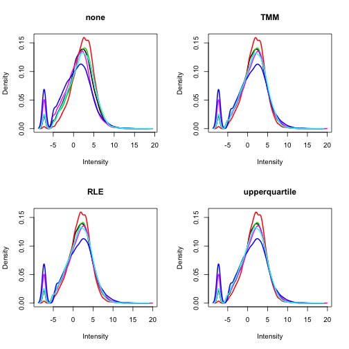

```
##   [,1]         [,2]         [,3]         [,4]
## X Numeric,3072 Numeric,3072 Numeric,3072 Numeric,3072
## Y Numeric,3072 Numeric,3072 Numeric,3072 Numeric,3072
```

```r
par(mfrow=c(2,2))
mapply(plotDensities, norms, edgeR_methods, MoreArgs=list(group=NULL, col=NULL, legend=FALSE))
```

## Question 2 code

```r
# Extract the normalization factors
norm_factors <- sapply(dges, function(x) x$samples$norm.factors)
colnames(norm_factors) <- edgeR_methods
```

## Question 2 plot

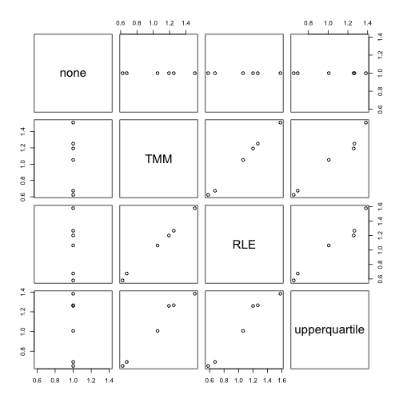

```r
plot(as.data.frame(norm_factors))
```

## Question 3 code

```r
# Create DGEList-object from the trimmed em
dge <- DGEList(trimmed_em)
dge <- calcNormFactors(object=dge, method="TMM")

# calculate log cpm values
TMM_v <- cpm(x=dge, log=TRUE, prior.count=0.1)
TMM_w <- cpm(x=dge, log=TRUE, prior.count=1.0)
TMM_x <- cpm(x=dge, log=TRUE, prior.count=5.0)
TMM_y <- cpm(x=dge, log=TRUE, prior.count=10.0)
TMM_z <- cpm(x=dge, log=TRUE, prior.count=20.0)
```

## Question 3 plot v

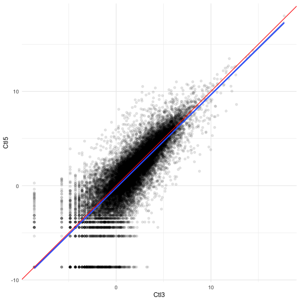

```r
qplot(data=as.data.frame(TMM_v), x=Ctl3, y=Ctl5, alpha=I(0.1)) + geom_smooth(method="gam") + geom_abline(color="red")
```

## Question 3 plot w

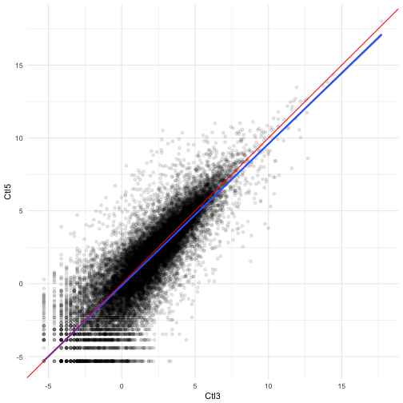

```r
qplot(data=as.data.frame(TMM_w), x=Ctl3, y=Ctl5, alpha=I(0.1)) + geom_smooth(method="gam") + geom_abline(color="red")
```

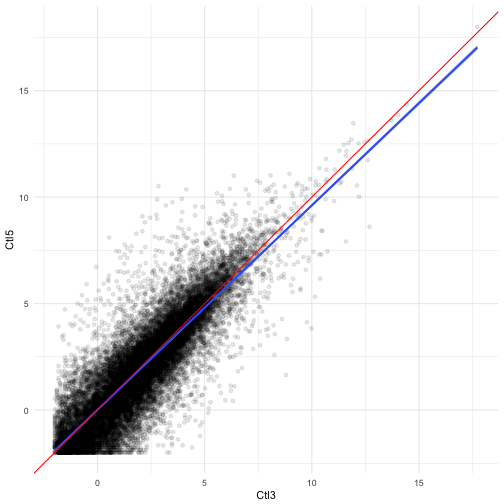

```r
qplot(data=as.data.frame(TMM_y), x=Ctl3, y=Ctl5, alpha=I(0.1)) + geom_smooth(method="gam") + geom_abline(color="red")
```

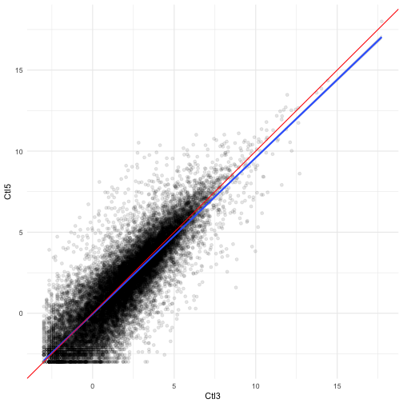

```r
qplot(data=as.data.frame(TMM_x), x=Ctl3, y=Ctl5, alpha=I(0.1)) + geom_smooth(method="gam") + geom_abline(color="red")
```

## Question 3 plot z

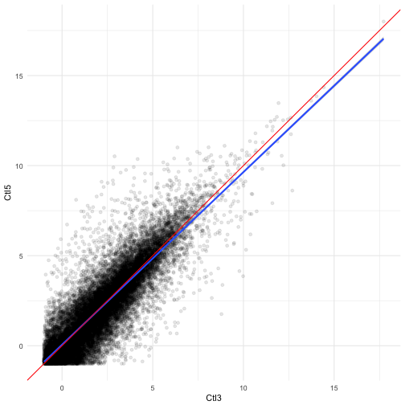

```r
qplot(data=as.data.frame(TMM_z), x=Ctl3, y=Ctl5, alpha=I(0.1)) + geom_smooth(method="gam") + geom_abline(color="red")
```